# Portfolio Project - Part 1

Jasmin Mousavi

10/7/2019

< Back to Portfolio

## **Gun Violence in the USA**

> Why did I choose this topic?

Recently I have noticed many gun violence incidents. It is to the point where there have been more incidents than there have been days in this year. Hearing about such violences that happen every day makes this country immune to this type of news, when it should be taken more seriously.

I am interested in seeing trends that exist in gun violience and discover if there are any ways to predict or lessen such violences. I know that twitter has the ability to predict social unrest, and would be interested in finding out if such violences could be predicted through analyzing social media content.

> What variables am I using?

- Categorical variables:
  - incident_id - unique identifier for each incident
  - participant_name - the name of the participant involved in the incident
  - participant_age_group - participants categorizied into age ranges
  - participant_gender - participant gender
  - participant_status - describes if the participant was killed, injured, arrested, or unharmed
  - participant_type - describes if the participant was a victim or suspect/subject
  - state_house_district - the state house district number that incident occured in
  - state_senate_district - the state senate district number that incident occured in
  - congressional_district - the congressional district number that incident occured in
  - state - state that incident occured in
  - city_or_county - city or county that incident occured in
  - gun_stolen - if gun was stolen
  - gun_type - what type of gun was used
  - incident_characteristics - notes/characteristics of incident
- Continuous variables:
  - age - age of participant involved in incident
  - n_killed - number of people killed in incident
  - n_injured - number of people ingured in incident
  - n_guns_involed - number of guns involved in incident
  - latitude - latitude of incident
  - longitude - longitude of incident
  - date - date of incident occurence

> How should we break up these variables?
- Want to separate all these variables into separate tables, that make sense together
  - separating the tables will not only help us clean up our data, but also makes it easier to analyze as the variables are grouped together
- Want to keep incident id in every table in order to ensure we can connect the tables to one another in the future

### Tables

1. Participant_Info
- incident_id"
- “participant_name”
- “participant_age”
- “participant_age_group”
- “participant_gender”
2. Participante_Incident_Info
- “incident_id”
- “participant_name”
- “participant_status”
- “participant_type”
3. Gun_Info
- “incident_id”
- “participant_name”
- “gun_stolen”
- “gun_type”
4. Incident_Stats
- “incident_id”
- “date”
- “state”
- “city_or_county”
- “latitude”
- “longitude”
- “n_killed”
- “n_guns_involved”
- “n_injured”
5. Incident_Government_Info
- “incident_id”
- “state_house_district”
- “state_senate_district”
- “congressional_district”
6. Incident_Characteristics
- “incident_id”
- “incident_characteristics”

## 1. Install Packages and Include Libraries

- We want to install the following packages for libraries that we will be using throughout the project

```r
install.packages("tidyverse", repos="http://cran.us.r-project.org")  #data wrangling
install.packages("dplyr", repos="http://cran.us.r-project.org")      #data wrangling
install.packages("lubridate", repos="http://cran.us.r-project.org")  #date transforming
```

```r
install.packages("ggplot2", repos="http://cran.us.r-project.org")    #graphs, plots, visualizations
install.packages("usmap", repos="http://cran.us.r-project.org")      #usa map visualization
install.packages("reshape2", repos="http://cran.us.r-project.org")   #used to reshape data frames
# If you are using mac, you will need to install XQuarts on your machine: https://www.xquartz.org/
install.packages("summarytools", repos="http://cran.us.r-project.org") #used to describe data frames
#load necessary libraries
library("tidyverse")
library("dplyr")
library("lubridate")
library("ggplot2")
library("usmap")
library(reshape2)
library(summarytools)
library(knitr)
```

## 2. Load Data

- Download the dataset from https://www.kaggle.com/jameslko/gun-violence-data and store it in the same directory in order to load it

```r
gun_violence <- read_csv("./gun-violence-data_01-2013_03-2018.csv")
```

## 3. Tidy Data

- We will begin cleaning our data by separating the variables into different tables.
- Separating data into different tables allows us to group together variables that make sense together, also making our data easier to understand.
- We also need to make sure our variables are converted to the correct format (numbers should be numbers, dates should be dates, strings should be strings, etc.)

> Creating the Participant_Info table

```r
#make tibble of selected variables
Participant_Info <- tibble(
  incident_id=gun_violence$incident_id,
  participant_name=gun_violence$participant_name,
  participant_age=gun_violence$participant_age,
  participant_age_group=gun_violence$participant_age_group,
  participant_gender=gun_violence$participant_gender)

head(Participant_Info)
```

```
## # A tibble: 6 x 5
##   incident_id participant_name participant_age participant_age… participant_gen…
##         <dbl> <chr>            <chr>           <chr>            <chr>
## 1      461105 0::Julian Sims   0::20           0::Adult 18+||1… 0::Male||1::Mal…
## 2      460726 0::Bernard Gill… 0::20           0::Adult 18+||1… 0::Male
## 3      478855 0::Damien Bell|… 0::25||1::31||… 0::Adult 18+||1… 0::Male||1::Mal…
## 4      478925 0::Stacie Philb… 0::29||1::33||… 0::Adult 18+||1… 0::Female||1::M…
## 5      478959 0::Danielle Ima… 0::18||1::46||… 0::Adult 18+||1… 0::Female||1::M…
## 6      478948 0::Rebeika Powe… 0::23||1::23||… 0::Adult 18+||1… 0::Female||1::F…
```

- As you can see the data is not cleaned and uses each observation as a single incident that holds many variables that are mapped to eachother
- The observations are mapped to one another in the following formats:
  - (some number)::{data we care about}||::{data we care about} and so on…
  - (some number):{data we care about}||
  - (some number)::{data we care about}|
- In order to clean this up, we should:
  - First, we separate the rows by “||”
  - Then, we match the rows together by their corresponding number “::”
  - Lastly, we take out the mappings: “::”

```r
#separate rows & match mappings
Participant_Info <- Participant_Info %>%
  separate_rows(participant_name, sep="\\|\\|", convert=TRUE)

Participant_Info <- Participant_Info %>%
  separate_rows(participant_age, sep="\\|\\|", convert=TRUE)

Participant_Info <- subset(Participant_Info, substr(participant_name, 0, 1)==substr(participant_age, 0, 1))

Participant_Info <- Participant_Info %>%
  separate_rows(participant_age_group, sep="\\|\\|", convert=TRUE)
Participant_Info <- Participant_Info %>%
  separate_rows(participant_age_group, sep="\\|", convert=TRUE)

Participant_Info <- subset(Participant_Info, substr(participant_name, 0, 1)==substr(participant_age_group, 0, 1))

Participant_Info <- Participant_Info %>%
  separate_rows(participant_gender, sep="\\|\\|", convert=TRUE)
Participant_Info <- Participant_Info %>%
  separate_rows(participant_gender, sep="\\|", convert=TRUE)

Participant_Info <- subset(Participant_Info, substr(participant_name, 0, 1)==substr(participant_gender, 0, 1))


#take out mappings
Participant_Info$participant_name <- gsub("^\\d+::", "", Participant_Info$participant_name)
Participant_Info$participant_age <- gsub("^\\d+::", "", Participant_Info$participant_age)
Participant_Info$participant_age_group <- gsub("^\\d+::", "", Participant_Info$participant_age_group)
Participant_Info$participant_gender <- gsub("^\\d+::", "", Participant_Info$participant_gender)
Participant_Info$participant_age_group <- gsub("^\\d+:", "", Participant_Info$participant_age_group)
Participant_Info$participant_gender <- gsub("^\\d+:", "", Participant_Info$participant_gender)
```

- I want to note here that as we have separated the rows, the incident_id is no longer unique and has multiple instances
- The last step for this table is the factor together the categorical variables
  - Factoring will group together categorical variables into levels
  - This will help us view and analyze the data
- I also want to make sure that the age is numeric
  - Since the data was read in as a string, we want to ensure that the age is numeric, now that we have cleaned it up

```r
#convert factor
Participant_Info$participant_age_group <- as.factor(Participant_Info$participant_age_group)
Participant_Info$participant_gender <- as.factor(Participant_Info$participant_gender)
Participant_Info$incident_id <- as.factor(Participant_Info$incident_id)

#make sure that age is numeric and not categorical
Participant_Info$participant_age <- as.numeric(Participant_Info$participant_age)
head(Participant_Info)
```

```
## # A tibble: 6 x 5
##   incident_id participant_name participant_age participant_age… participant_gen…
##   <fct>       <chr>                      <dbl> <fct>            <fct>
## 1 461105      Julian Sims                   20 Adult 18+        Male
## 2 460726      Bernard Gillis                20 Adult 18+        Male
## 3 478855      Damien Bell                   25 Adult 18+        Male
## 4 478855      Desmen Noble                  31 Adult 18+        Male
## 5 478855      Herman Seagers                33 Adult 18+        Male
## 6 478855      Ladd Tate Sr                  34 Adult 18+        Male
```

> Creating the Participant_Incident_Info table

```r
#make tibble of selected variables
Participant_Incident_Info <- tibble(
  incident_id=gun_violence$incident_id,
  participant_name=gun_violence$participant_name,
  participant_status=gun_violence$participant_status,
  participant_type=gun_violence$participant_type)

head(Participant_Incident_Info)
```

```
## # A tibble: 6 x 4
##   incident_id participant_name       participant_status    participant_type
##         <dbl> <chr>                  <chr>                 <chr>
## 1      461105 0::Julian Sims         0::Arrested||1::Inju… 0::Victim||1::Victim…
## 2      460726 0::Bernard Gillis      0::Killed||1::Injure… 0::Victim||1::Victim…
## 3      478855 0::Damien Bell||1::De… 0::Injured, Unharmed… 0::Subject-Suspect||…
## 4      478925 0::Stacie Philbrook||… 0::Killed||1::Killed… 0::Victim||1::Victim…
## 5      478959 0::Danielle Imani Jam… 0::Injured||1::Injur… 0::Victim||1::Victim…
## 6      478948 0::Rebeika Powell||1:… 0::Killed||1::Killed… 0::Victim||1::Victim…
```

- As you can see the data is not cleaned and uses each observation as a single incident that holds many variables that are mapped to eachother, *just like our Participant_Info table*
- The observations are mapped to one another in the following formats:
  - (some number)::{data we care about}||::{data we care about} and so on…
  - (some number):{data we care about}||
  - (some number)::{data we care about}|
- In order to clean this up, we should:
  - First, we separate the rows by “||”
  - Then, we match the rows together by their corresponding number “::”
  - Lastly, we take out the mappings: “::”

```r
#separate rows & match mappings
Participant_Incident_Info <- Participant_Incident_Info %>%
  separate_rows(participant_name, sep="\\|\\|", convert=TRUE)

Participant_Incident_Info <- Participant_Incident_Info %>%
  separate_rows(participant_status, sep="\\|\\|", convert=TRUE)
Participant_Incident_Info <- Participant_Incident_Info %>%
  separate_rows(participant_status, sep="\\|", convert=TRUE)

Participant_Incident_Info <- subset(Participant_Incident_Info, substr(participant_name, 0, 1)==substr(participant_status, 0, 1))

Participant_Incident_Info <- Participant_Incident_Info %>%
  separate_rows(participant_type, sep="\\|\\|", convert=TRUE)
Participant_Incident_Info <- Participant_Incident_Info %>%
  separate_rows(participant_type, sep="\\|", convert=TRUE)

Participant_Incident_Info <- subset(Participant_Incident_Info, substr(participant_name, 0, 1)==substr(participant_type, 0, 1))


#take out mappings
Participant_Incident_Info$participant_name <- gsub("^\\d+::", "", Participant_Incident_Info$participant_name)
Participant_Incident_Info$participant_name <- gsub("^\\d+:", "", Participant_Incident_Info$participant_name)
Participant_Incident_Info$participant_status <- gsub("^\\d+::", "", Participant_Incident_Info$participant_status)
Participant_Incident_Info$participant_status <- gsub("^\\d+:", "", Participant_Incident_Info$participant_status)
Participant_Incident_Info$participant_type <- gsub("^\\d+::", "", Participant_Incident_Info$participant_type)
Participant_Incident_Info$participant_type <- gsub("^\\d+:", "", Participant_Incident_Info$participant_type)
```

- I want to note here that as we have separated the rows, the incident_id is no longer unique and has multiple instances
- The last step for this table is the factor together the categorical variables
  - Factoring will group together categorical variables into levels
  - This will help us view and analyze the data

```r
#convert to factor
Participant_Incident_Info$participant_status <- as.factor(Participant_Incident_Info$participant_status)
Participant_Incident_Info$participant_type <- as.factor(Participant_Incident_Info$participant_type)
Participant_Incident_Info$incident_id <- as.factor(Participant_Incident_Info$incident_id)

head(Participant_Incident_Info)
```

```
## # A tibble: 6 x 4
##   incident_id participant_name participant_status          participant_type
##   <fct>       <chr>            <fct>                       <fct>
## 1 461105      Julian Sims      Arrested                    Victim
## 2 460726      Bernard Gillis   Killed                      Victim
## 3 478855      Damien Bell      Injured, Unharmed, Arrested Subject-Suspect
## 4 478855      Desmen Noble     Unharmed, Arrested          Subject-Suspect
## 5 478855      Herman Seagers   Killed                      Victim
## 6 478855      Ladd Tate Sr     Injured                     Victim
```

> Creating the Gun_Info Table

```r
#make tibble of selected variables
Gun_Info <- tibble(
  incident_id=gun_violence$incident_id,
  participant_name=gun_violence$participant_name,
  gun_stolen=gun_violence$gun_stolen,
  gun_type=gun_violence$gun_type)

head(Gun_Info)
```

```
## # A tibble: 6 x 4
##   incident_id participant_name                       gun_stolen     gun_type
##         <dbl> <chr>                                  <chr>          <chr>
## 1      461105 0::Julian Sims                         <NA>           <NA>
## 2      460726 0::Bernard Gillis                      <NA>           <NA>
## 3      478855 0::Damien Bell||1::Desmen Noble||2::H… 0::Unknown||1… 0::Unknown|…
## 4      478925 0::Stacie Philbrook||1::Christopher R… <NA>           <NA>
## 5      478959 0::Danielle Imani Jameison||1::Mauric… 0::Unknown||1… 0::Handgun|…
## 6      478948 0::Rebeika Powell||1::Kayetie Melchor… <NA>           <NA>
```

- As you can see the data is not cleaned and uses each observation as a single incident that holds many variables that are mapped to eachother, *just like our previous two tables*
- The observations are mapped to one another in the following formats:
  - (some number)::{data we care about}||::{data we care about} and so on…
  - (some number):{data we care about}||
  - (some number)::{data we care about}|
- In order to clean this up, we should:
  - First, we separate the rows by “||”
  - Then, we match the rows together by their corresponding number “::”
  - Lastly, we take out the mappings: “::”

```r
#separate rows & match mappings
Gun_Info <- Gun_Info %>%
  separate_rows(participant_name, sep="\\|\\|", convert=TRUE)

Gun_Info <- Gun_Info %>%
  separate_rows(gun_stolen, sep="\\|\\|", convert=TRUE)
Gun_Info <- Gun_Info %>%
  separate_rows(gun_stolen, sep="\\|", convert=TRUE)

Gun_Info <- subset(Gun_Info, substr(participant_name, 0, 1)==substr(gun_stolen, 0, 1))

Gun_Info <- Gun_Info %>%
  separate_rows(gun_type, sep="\\|\\|", convert=TRUE)

Gun_Info <- subset(Gun_Info, substr(participant_name, 0, 1)==substr(gun_type, 0, 1))
#remove mappings
Gun_Info$participant_name <- gsub("^\\d+::", "", Gun_Info$participant_name)
Gun_Info$gun_stolen <- gsub("^\\d+::", "", Gun_Info$gun_stolen)
Gun_Info$gun_stolen <- gsub("^\\d+:", "", Gun_Info$gun_stolen)
Gun_Info$gun_type <- gsub("^\\d+::", "", Gun_Info$gun_type)
Gun_Info$gun_type <- gsub("^\\d+:", "", Gun_Info$gun_type)
```

- I want to note here that as we have separated the rows, the incident_id is no longer unique and has multiple instances
- The last step for this table is the factor together the categorical variables
  - Factoring will group together categorical variables into levels
  - This will help us view and analyze the data

```r
#convert to factor
Gun_Info$gun_stolen <- as.factor(Gun_Info$gun_stolen)
Gun_Info$gun_type <- as.factor(Gun_Info$gun_type)
Gun_Info$incident_id <- as.factor(Gun_Info$incident_id)

head(Gun_Info)
```

```
## # A tibble: 6 x 4
##   incident_id participant_name            gun_stolen gun_type
##   <fct>       <chr>                       <fct>      <fct>
## 1 478855      Damien Bell                 Unknown    Unknown
## 2 478855      Desmen Noble                Unknown    Unknown
## 3 478959      Danielle Imani Jameison     Unknown    Handgun
## 4 478959      Maurice Eugene Edmonds, Sr. Unknown    Handgun
## 5 479363      Greg Griego                 Unknown    22 LR
## 6 479363      Sara Griego                 Unknown    223 Rem [AR-15]
```

> Creating the Incident_Stats Table

```r
#make tibble of selected variables
Incident_Stats <- tibble(
  incident_id=gun_violence$incident_id,
  date=gun_violence$date,
  state=gun_violence$state,
  city_or_county=gun_violence$city_or_county,
  latitude=gun_violence$latitude,
  longitude=gun_violence$longitude,
  n_killed=gun_violence$n_killed,
  n_guns_involved=gun_violence$n_guns_involved,
  n_injured=gun_violence$n_injured)

head(Incident_Stats)
```

```
## # A tibble: 6 x 9
##   incident_id date       state city_or_county latitude longitude n_killed
##         <dbl> <date>     <chr> <chr>             <dbl>     <dbl>    <dbl>
## 1      461105 2013-01-01 Penn… Mckeesport         40.3     -79.9        0
## 2      460726 2013-01-01 Cali… Hawthorne          33.9    -118.         1
## 3      478855 2013-01-01 Ohio  Lorain             41.4     -82.1        1
## 4      478925 2013-01-05 Colo… Aurora             39.7    -105.         4
## 5      478959 2013-01-07 Nort… Greensboro         36.1     -80.0        2
## 6      478948 2013-01-07 Okla… Tulsa              36.2     -96.0        4
## # … with 2 more variables: n_guns_involved <dbl>, n_injured <dbl>
```

- Here I want to convert the date to a format that R can recognize as date
  - This will make it easier to manipulate and analyze
  - We will use the POSIXlt function to convert the date
- We also want to convert the id to a character (not a factor)
  - I want to note here that since we did not separate the rows, the incident id will be unique in tihs table
- Lastly, we will convert the state to a factor
  - Factoring will group together categorical variables into levels
  - This will help us view and analyze the data

```r
Incident_Stats$date<- as.POSIXlt(parse_datetime(as.character(Incident_Stats$date), format="%Y-%m-%d"))

#need to make incident id categorical
Incident_Stats$incident_id <- as.character(Incident_Stats$incident_id)
#convert state to factor
Incident_Stats$state <- as.factor(Incident_Stats$state)
Incident_Stats$city_or_county <- as.factor(Incident_Stats$city_or_county)

head(Incident_Stats)
```

```
## # A tibble: 6 x 9
##   incident_id date                state city_or_county latitude longitude
##   <chr>       <dttm>              <fct> <fct>             <dbl>     <dbl>
## 1 461105      2013-01-01 00:00:00 Penn… Mckeesport         40.3     -79.9
## 2 460726      2013-01-01 00:00:00 Cali… Hawthorne          33.9    -118.
## 3 478855      2013-01-01 00:00:00 Ohio  Lorain             41.4     -82.1
## 4 478925      2013-01-05 00:00:00 Colo… Aurora             39.7    -105.
## 5 478959      2013-01-07 00:00:00 Nort… Greensboro         36.1     -80.0
## 6 478948      2013-01-07 00:00:00 Okla… Tulsa              36.2     -96.0
## # … with 3 more variables: n_killed <dbl>, n_guns_involved <dbl>,
## #   n_injured <dbl>
```

> Creating the Incident_Government_Info Table

```r
#make tibble of selected variables
Incident_Government_Info <- tibble(
  incident_id=gun_violence$incident_id,
  state_house_district=gun_violence$state_house_district,
  state_senate_district=gun_violence$state_senate_district,
  congressional_district=gun_violence$congressional_district)

head(Incident_Government_Info)
```

```
## # A tibble: 6 x 4
##   incident_id state_house_district state_senate_district congressional_district
##         <dbl>                <dbl>                 <dbl>                  <dbl>
## 1      461105                   NA                    NA                     14
## 2      460726                   62                    35                     43
## 3      478855                   56                    13                      9
## 4      478925                   40                    28                      6
## 5      478959                   62                    27                      6
## 6      478948                   72                    11                      1
```

- We also want to convert the id to a character (not a factor)
  - I want to note here that since we did not separate the rows, the incident id will be unique in tihs table
- Lastly, we will convert the house, senate, congressional districts to factor
  - Although the districts are numeric, they represent a specific district, therefore making it categorical
  - Factoring will group together categorical variables into levels
  - This will help us view and analyze the data

```r
#need to make incident id categorical
Incident_Government_Info$incident_id <- as.character(Incident_Government_Info$incident_id)
Incident_Government_Info$state_house_district<- as.factor(Incident_Government_Info$state_house_district)
Incident_Government_Info$state_senate_district <- as.factor(Incident_Government_Info$state_senate_district)
Incident_Government_Info$congressional_district <- as.factor(Incident_Government_Info$congressional_district)

head(Incident_Government_Info)
```

```
## # A tibble: 6 x 4
##   incident_id state_house_district state_senate_district congressional_district
##   <chr>       <fct>                <fct>                 <fct>
## 1 461105      <NA>                 <NA>                  14
## 2 460726      62                   35                    43
## 3 478855      56                   13                    9
## 4 478925      40                   28                    6
## 5 478959      62                   27                    6
## 6 478948      72                   11                    1
```

> Lastly, we will make our Incident_Characteristics table

```r
#make tibble of selected variables
Incident_Characteristics <- tibble(
  incident_id=gun_violence$incident_id,
  incident_characteristics=gun_violence$incident_characteristics)

head(Incident_Characteristics)
```

```
## # A tibble: 6 x 2
##   incident_id incident_characteristics
##         <dbl> <chr>
## 1      461105 Shot - Wounded/Injured||Mass Shooting (4+ victims injured or kill…
## 2      460726 Shot - Wounded/Injured||Shot - Dead (murder, accidental, suicide)…
## 3      478855 Shot - Wounded/Injured||Shot - Dead (murder, accidental, suicide)…
## 4      478925 Shot - Dead (murder, accidental, suicide)||Officer Involved Incid…
## 5      478959 Shot - Wounded/Injured||Shot - Dead (murder, accidental, suicide)…
## 6      478948 Shot - Dead (murder, accidental, suicide)||Home Invasion||Home In…
```

- As you can see the data is not cleaned and uses each observation as a single incident that holds many variables
- The observations are mapped to one another in the following format:
  - {data we care about}||
- We separate the rows by “||”

```r
#separate rows
Incident_Characteristics <- Incident_Characteristics %>%
  separate_rows(incident_characteristics, sep="\\|\\|", convert=TRUE)
```

- I want to note here that as we have separated the rows, the incident_id is no longer unique and has multiple instances
- The last step for this table is the factor together the categorical variables
  - Factoring will group together categorical variables into levels
  - This will help us view and analyze the data

```r
#convert to factor
Incident_Characteristics$incident_id <- as.factor(Incident_Characteristics$incident_id)
Incident_Characteristics$incident_characteristics<- as.factor(Incident_Characteristics$incident_characteristics)

head(Incident_Characteristics)
```

```
## # A tibble: 6 x 2
##   incident_id incident_characteristics
##   <fct>       <fct>
## 1 461105      Shot - Wounded/Injured
## 2 461105      Mass Shooting (4+ victims injured or killed excluding the subject…
## 3 461105      Possession (gun(s) found during commission of other crimes)
## 4 461105      Possession of gun by felon or prohibited person
## 5 460726      Shot - Wounded/Injured
## 6 460726      Shot - Dead (murder, accidental, suicide)
```

## 4. Exploring our Data through Visualizations and Statistics

First, we will set our summarytools settings

```r
st_options(bootstrap.css     = FALSE,       # Already part of the theme so no need for it
           plain.ascii       = FALSE,       # One of the essential settings
           style             = "rmarkdown", # Idem.
           dfSummary.silent  = TRUE,        # Suppresses messages about temporary files
           footnote          = NA,          # Keeping the results minimalistic
           subtitle.emphasis = FALSE)       # For the vignette theme, this gives
                                            # much better results. Your mileage may vary.
opts_chunk$set(comment=NA, prompt=FALSE, cache=FALSE, echo=TRUE, results='asis') #kniter options
st_css() #css for summarytools
```

[output not shown]

### Exploring our Incident_Government_Info Table

First, lets look at a quick summary of our table

```r
dfSummary(Incident_Government_Info, style="grid", graph.col=FALSE, max.distinct.values=5, valid.col=FALSE)
```

### Data Frame Summary

**Incident_Government_Info**  
**Dimensions:** 239677 x 4  
**Duplicates:** 0

| No | Variable | Stats / Values | Freqs (% of Valid) | Missing |
| --- | --- | --- | --- | --- |
| 1 | incident_id [character] | 1. 1000004 2. 1000007 3. 1000009 4. 100003 5. 1000042 [ 239672 others ] | 1 ( 0.0%) 1 ( 0.0%) 1 ( 0.0%) 1 ( 0.0%) 1 ( 0.0%) 239672 (100.0%) | 0 (0%) |
| 2 | state_house_district [factor] | 1. 1 2. 2 3. 3 4. 4 5. 5 [ 270 others ] | 2056 ( 1.0%) 2941 ( 1.5%) 3064 ( 1.5%) 1928 ( 1.0%) 2603 ( 1.3%) 188313 (93.7%) | 38772 (16.18%) |
| 3 | state_senate_district [factor] | 1. 1 2. 2 3. 3 4. 4 5. 5 [ 63 others ] | 5206 ( 2.5%) 6666 ( 3.2%) 7837 ( 3.8%) 7328 ( 3.5%) 10041 ( 4.8%) 170264 (82.1%) | 32335 (13.49%) |
| 4 | congressional_district [factor] | 1. 0 2. 1 3. 2 4. 3 5. 4 [ 49 others ] | 421 ( 0.2%) 36910 (16.2%) 26945 (11.8%) 20621 ( 9.1%) 18469 ( 8.1%) 124367 (54.6%) | 11944 (4.98%) |

Now lets take a closer look at the most frequent variables in the house, senate, and congress districts

```r
freq(Incident_Government_Info$state_house_district, plain.ascii = FALSE, style = "rmarkdown", order="freq", rows=1:5)
```

### Frequencies

**Incident_Government_Info$state_house_district**  
**Type:** Factor

|  | Freq | % Valid | % Valid Cum. | % Total | % Total Cum. |
| --- | --- | --- | --- | --- | --- |
| **18** | 3476 | 1.73 | 1.73 | 1.45 | 1.45 |
| **10** | 3411 | 1.70 | 3.43 | 1.42 | 2.87 |
| **32** | 3218 | 1.60 | 5.03 | 1.34 | 4.22 |
| **31** | 3192 | 1.59 | 6.62 | 1.33 | 5.55 |
| **3** | 3064 | 1.53 | 8.14 | 1.28 | 6.83 |
| **(Other)** | 184544 | 91.86 | 100.00 | 77.00 | 83.82 |
| **<NA>** | 38772 |  |  | 16.18 | 100.00 |
| **Total** | 239677 | 100.00 | 100.00 | 100.00 | 100.00 |

```r
freq(Incident_Government_Info$state_senate_district, plain.ascii = FALSE, style = "rmarkdown", order="freq", rows=1:5)
```

### Frequencies

**Incident_Government_Info$state_senate_district**  
**Type:** Factor

|  | Freq | % Valid | % Valid Cum. | % Total | % Total Cum. |
| --- | --- | --- | --- | --- | --- |
| **5** | 10041 | 4.84 | 4.84 | 4.19 | 4.19 |
| **9** | 7963 | 3.84 | 8.68 | 3.32 | 7.51 |
| **3** | 7837 | 3.78 | 12.46 | 3.27 | 10.78 |
| **4** | 7328 | 3.53 | 16.00 | 3.06 | 13.84 |
| **2** | 6666 | 3.21 | 19.21 | 2.78 | 16.62 |
| **(Other)** | 167507 | 80.79 | 100.00 | 69.89 | 86.51 |
| **<NA>** | 32335 |  |  | 13.49 | 100.00 |
| **Total** | 239677 | 100.00 | 100.00 | 100.00 | 100.00 |

```r
freq(Incident_Government_Info$congressional_district, plain.ascii = FALSE, style = "rmarkdown", order="freq", rows=1:5)
```

### Frequencies

**Incident_Government_Info$congressional_district**  
**Type:** Factor

|  | Freq | % Valid | % Valid Cum. | % Total | % Total Cum. |
| --- | --- | --- | --- | --- | --- |
| **1** | 36910 | 16.21 | 16.21 | 15.40 | 15.40 |
| **2** | 26945 | 11.83 | 28.04 | 11.24 | 26.64 |
| **3** | 20621 | 9.05 | 37.09 | 8.60 | 35.25 |
| **7** | 19709 | 8.65 | 45.75 | 8.22 | 43.47 |
| **4** | 18469 | 8.11 | 53.86 | 7.71 | 51.17 |
| **(Other)** | 105079 | 46.14 | 100.00 | 43.84 | 95.02 |
| **<NA>** | 11944 |  |  | 4.98 | 100.00 |
| **Total** | 239677 | 100.00 | 100.00 | 100.00 | 100.00 |

- The house district with the most incidents is district 18.
- The senate district with the most incidents is district 5.
- The congressional district with the most incidents is district 1.

### Exploring our Incident_Stats table

First, lets take a look at a summary of our table

```r
incident_stats <- Incident_Stats
incident_stats$date <- ymd(incident_stats$date)  #need to format of date in order to work with dfSummary()
dfSummary(incident_stats, style="grid", graph.col=FALSE, max.distinct.values=5, valid.col=FALSE)
```

### Data Frame Summary

**incident_stats**  
**Dimensions:** 239677 x 9  
**Duplicates:** 0

| No | Variable | Stats / Values | Freqs (% of Valid) | Missing |
| --- | --- | --- | --- | --- |
| 1 | incident_id [character] | 1. 1000004 2. 1000007 3. 1000009 4. 100003 5. 1000042 [ 239672 others ] | 1 ( 0.0%) 1 ( 0.0%) 1 ( 0.0%) 1 ( 0.0%) 1 ( 0.0%) 239672 (100.0%) | 0 (0%) |
| 2 | date [Date] | min : 2013-01-01 med : 2016-04-05 max : 2018-03-31 range : 5y 2m 30d | 1725 distinct values | 0 (0%) |
| 3 | state [factor] | 1. Alabama 2. Alaska 3. Arizona 4. Arkansas 5. California [ 46 others ] | 5471 ( 2.3%) 1349 ( 0.6%) 2328 ( 1.0%) 2842 ( 1.2%) 16306 ( 6.8%) 211381 (88.2%) | 0 (0%) |
| 4 | city_or_county [factor] | 1. Abbeville 2. Abbotsford 3. Abbott 4. Abbott Township 5. Abbottstown [ 12816 others ] | 37 ( 0.0%) 3 ( 0.0%) 1 ( 0.0%) 1 ( 0.0%) 1 ( 0.0%) 239634 (100.0%) | 0 (0%) |
| 5 | latitude [numeric] | Mean (sd) : 37.5 (5.1) min < med < max: 19.1 < 38.6 < 71.3 IQR (CV) : 7.5 (0.1) | 101240 distinct values | 7923 (3.31%) |
| 6 | longitude [numeric] | Mean (sd) : -89.3 (14.4) min < med < max: -171.4 < -86.2 < 97.4 IQR (CV) : 14.1 (-0.2) | 112347 distinct values | 7923 (3.31%) |
| 7 | n_killed [numeric] | Mean (sd) : 0.3 (0.5) min < med < max: 0 < 0 < 50 IQR (CV) : 0 (2.1) | 16 distinct values | 0 (0%) |
| 8 | n_guns_involved [numeric] | Mean (sd) : 1.4 (4.7) min < med < max: 1 < 1 < 400 IQR (CV) : 0 (3.4) | 106 distinct values | 99451 (41.49%) |
| 9 | n_injured [numeric] | Mean (sd) : 0.5 (0.7) min < med < max: 0 < 0 < 53 IQR (CV) : 1 (1.5) | 23 distinct values | 0 (0%) |

```r
summary(incident_stats)
```

incident_id date state  
Length:239677 Min. :2013-01-01 Illinois : 17556  
Class :character 1st Qu.:2015-03-07 California: 16306  
Mode :character Median :2016-04-05 Florida : 15029  
Mean :2016-03-13 Texas : 13577  
3rd Qu.:2017-04-03 Ohio : 10244  
Max. :2018-03-31 New York : 9712  
(Other) :157253  
city_or_county latitude longitude n_killed  
Chicago : 10814 Min. :19.11 Min. :-171.43 Min. : 0.0000  
Baltimore : 3943 1st Qu.:33.90 1st Qu.: -94.16 1st Qu.: 0.0000  
Washington : 3279 Median :38.57 Median : -86.25 Median : 0.0000  
New Orleans : 3084 Mean :37.55 Mean : -89.34 Mean : 0.2523  
Philadelphia: 2963 3rd Qu.:41.44 3rd Qu.: -80.05 3rd Qu.: 0.0000  
Houston : 2501 Max. :71.34 Max. : 97.43 Max. :50.0000  
(Other) :213093 NA’s :7923 NA’s :7923  
n_guns_involved n_injured  
Min. : 1.00 Min. : 0.000  
1st Qu.: 1.00 1st Qu.: 0.000  
Median : 1.00 Median : 0.000  
Mean : 1.37 Mean : 0.494  
3rd Qu.: 1.00 3rd Qu.: 1.000  
Max. :400.00 Max. :53.000  
NA’s :99451  
Now lets take a closer look at some of our variables to answer some questions > How many incidents do we have each year?

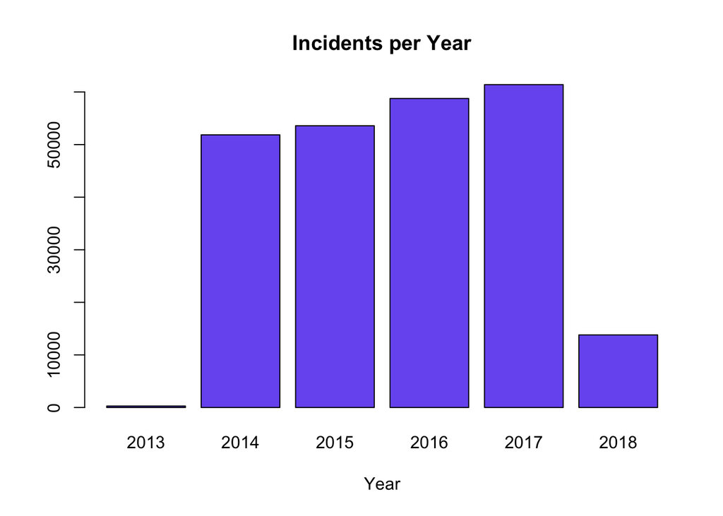

```r
year <- table(year=year(Incident_Stats$date)) #create data frame that separates the year

#Plot the data
barplot(year, main="Incidents per Year", xlab="Year", col="#785EF0")
```

- 2017 has the most incidents, followed by 2016.
- One thing to note here is that the dataset does not include the all the months of 2018.
- However, 2013 is strangely low, and it is something we should take a closer look at in the future.
  - Perhaps not all the months are in the dataset (as the should be), or maybe the python script didn’t get all the observations.

> What is the average incidents per month?

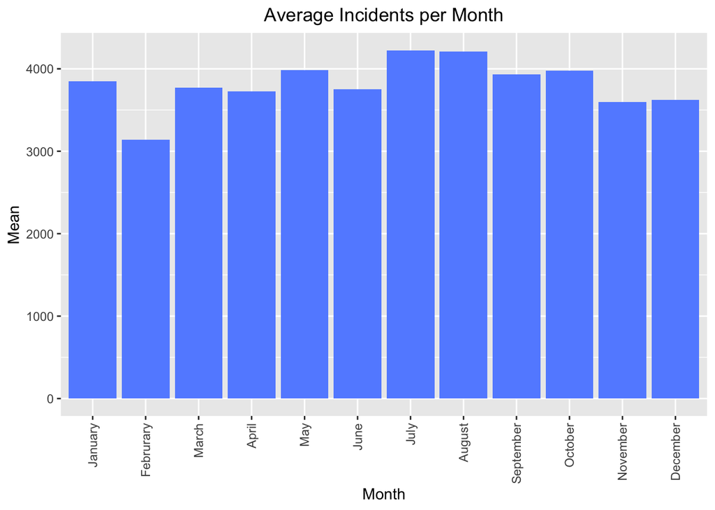

```r
#create a data frame that separates the year, month, and day from the date
df <- data.frame(date=Incident_Stats$date)
df$month <- month(df$date)
df$year <- year(df$date)

#group together by year, month, and day
df$year <- as.factor(df$year)
count <- df %>%
  group_by(year) %>%
  count(month) %>%
  group_by(month) %>%
  summarise(mean=mean(n)) #gather the means of the groups
count$month <- as.factor(count$month) #group together the months into categories/levels

#Plot the data
ggplot(count, aes(x=month, y=mean)) +
  geom_bar(stat="identity",fill="#648FFF" ) +
  labs(x="Month", y="Mean")+
  ggtitle("Average Incidents per Month")+
  scale_x_discrete(labels=c("January","Februrary","March","April","May","June","July","August","September","October","November","December"))+
  theme(axis.text.x=element_text(angle=90,hjust=1,vjust=0.5),
        plot.title = element_text(hjust=0.5))
```

- July and August have the highest incidents per month

> What states have the most incidents?

```r
UsaMap <- Incident_Stats
UsaMap <- UsaMap %>% count(state)  # create a data frame of the counts per state
UsaMap$state <- as.factor(UsaMap$state)
UsaMap
```

# A tibble: 51 x 2

state n 1 Alabama 5471 2 Alaska 1349 3 Arizona 2328 4 Arkansas 2842 5 California 16306 6 Colorado 3201 7 Connecticut 3067 8 Delaware 1685 9 District of Columbia 3195 10 Florida 15029 # … with 41 more rows

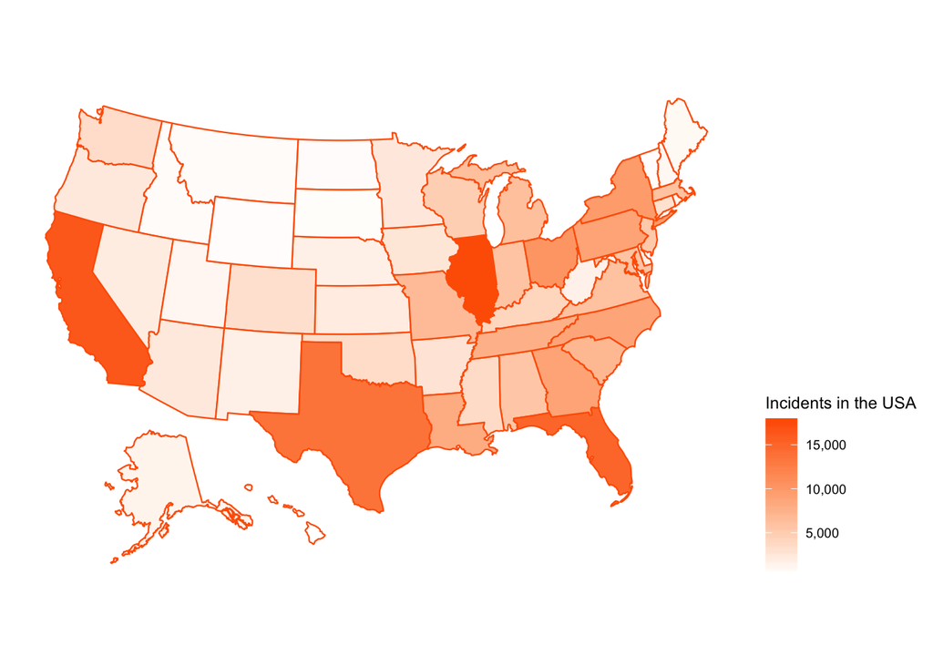

```r
#Plot the data
plot_usmap(data = UsaMap, values = "n", color = "#FE6100") +
  scale_fill_continuous(
    low = "white", high = "#FE6100", name = "Incidents in the USA", label = scales::comma
  ) + theme(legend.position = "right")
```

> How many people were killed or injured for the incidents throughout the years?

```r
Stats_Total <- Incident_Stats
Stats_Total$date <- ymd(Stats_Total$date) #change the date format to work better with our graph
Stats_Total$n_injured <- as.numeric(Stats_Total$n_injured) #need to make sure this is numeric in order to obtain total later
Stats_Total$n_killed <- as.numeric(Stats_Total$n_killed) #need to make sure this is numeric in order to obtain total
Stats_Total$total <- Stats_Total$n_injured + Stats_Total$n_killed #get the total

totals <- data.frame(total=Stats_Total$total,
                     injured=Stats_Total$n_injured,
                     killed=Stats_Total$n_killed,
                     date=Stats_Total$date) #create new data frame to reshape

# reshape data frame in order to have the columns as rows, and also have a column for the frequencies of each variable
melted_totals <- melt(totals, measure.vars = c("total","killed","injured"))

head(melted_totals)
```

```
    date variable value
```

1 2013-01-01 total 4 2 2013-01-01 total 4 3 2013-01-01 total 4 4 2013-01-05 total 4 5 2013-01-07 total 4 6 2013-01-07 total 4 * The reshaped data frame will be easier to graph

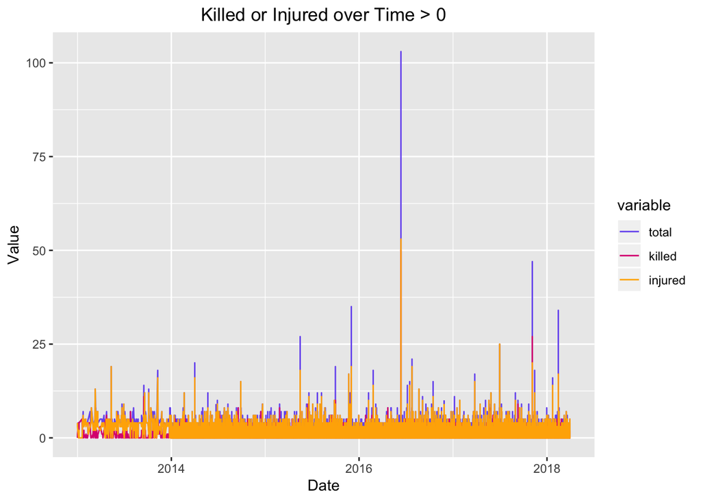

```r
#Plot the data
ggplot() +
  geom_line(data=melted_totals, aes(x=date, y=value, colour=variable)) +
  scale_color_manual(values=c("#785EF0", "#DC267F", "#FFB000" )) +
  xlab("Date") +
  ylab("Value") +
  ggtitle("Killed or Injured over Time > 0") +
  theme(plot.title = element_text(hjust=0.5))
```

- This is graph is ugly and hard to interperet, so lets limit our total amount of injured/killed to 10 or greater

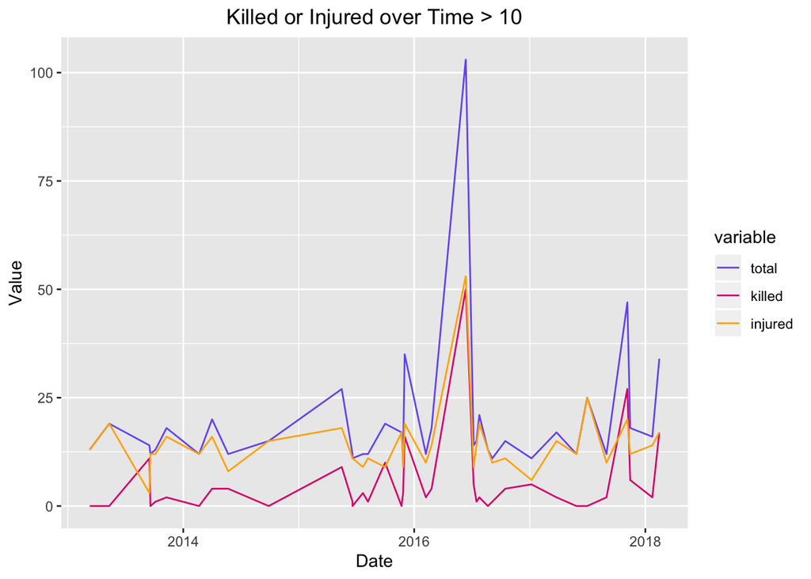

```r
#ugly lets limit it
Stats_Total <- Stats_Total %>% filter(total > 10) #filter total to be greater than 10

totals <- data.frame(total=Stats_Total$total,
                     injured=Stats_Total$n_injured,
                     killed=Stats_Total$n_killed,
                     date=Stats_Total$date) #create new data frame to reshape

# reshape data frame in order to have the columns as rows, and also have a column for the frequencies of each variable
melted_totals <- melt(totals, measure.vars = c("total","killed","injured"))

#Plot the data
ggplot() +
  geom_line(data=melted_totals, aes(x=date, y=value, colour=variable)) +
  scale_color_manual(values=c("#785EF0", "#DC267F", "#FFB000" )) +
  xlab("Date") +
  ylab("Value") +
  ggtitle("Killed or Injured over Time > 10") +
  theme(plot.title = element_text(hjust=0.5))
```

- Here we can see there was a huge spike in 2016, and a small spike in 2017
  - This is something we should investigate in the future

### Exploring our Gun_Info table

```r
dfSummary(Gun_Info, style="grid", graph.col=FALSE, max.distinct.values=5, valid.col=FALSE)
```

### Data Frame Summary

**Gun_Info**  
**Dimensions:** 130191 x 4  
**Duplicates:** 58317

| No | Variable | Stats / Values | Freqs (% of Valid) | Missing |
| --- | --- | --- | --- | --- |
| 1 | incident_id [factor] | 1. 92117 2. 92135 3. 92151 4. 92563 5. 92623 [ 66300 others ] | 1 ( 0.0%) 1 ( 0.0%) 1 ( 0.0%) 1 ( 0.0%) 1 ( 0.0%) 130186 (100.0%) | 0 (0%) |
| 2 | participant_name [character] | 1. Bassem Herz 2. Aliyah Camille Dowell 3. John Lewis Piotrowski 4. Algernon Tamasoa 5. Jennifer Marie Cash [ 67761 others ] | 3969 ( 3.0%) 3844 ( 3.0%) 3136 ( 2.4%) 2401 ( 1.8%) 625 ( 0.5%) 116216 (89.3%) | 0 (0%) |
| 3 | gun_stolen [factor] | 1. Not-stolen 2. Stolen 3. Unknown | 846 ( 0.7%) 13508 (10.4%) 115837 (89.0%) | 0 (0%) |
| 4 | gun_type [factor] | 1. 10mm 2. 12 gauge 3. 16 gauge 4. 20 gauge 5. 20 gauge\|1:16 gauge\|2:Oth [ 35 others ] | 28 ( 0.0%) 796 ( 0.6%) 14 ( 0.0%) 250 ( 0.2%) 1 ( 0.0%) 129102 (99.2%) | 0 (0%) |

```r
summary(Gun_Info)
```

incident_id participant_name gun_stolen gun_type  
575663 : 6862 Length:130191 Not-stolen: 846 Unknown:86075  
339002 : 4212 Class :character Stolen : 13508 Handgun:19236  
136646 : 3845 Mode :character Unknown :115837 9mm : 5149  
459274 : 3137 Rifle : 2894  
431754 : 3128 22 LR : 2392  
1059740: 1737 Shotgun: 2138  
(Other):107270 (Other):12307  
Now lets take a closer look at some of our variables to answer some questions

> What are the most common gun types?

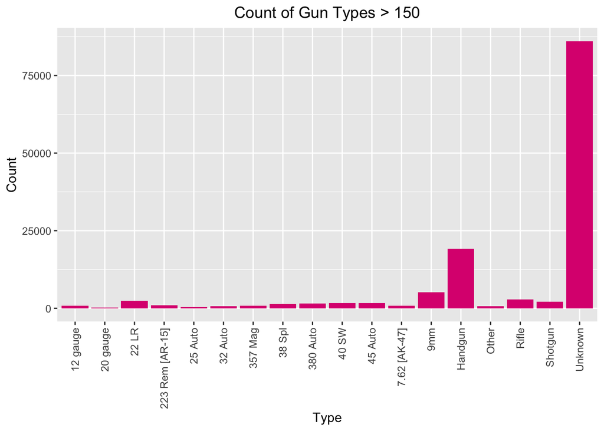

```r
Gun_Info_Type_Count <- Gun_Info %>% count(gun_type) #create a data frame of the counts of types of guns
#There are many different gun types, so we are going to only look at the gun types that occur more than 150 times
Gun_Info_Type_Count <- Gun_Info_Type_Count %>% filter(n > 150)

#Plot the data
ggplot(Gun_Info_Type_Count, aes(x=gun_type, y=n)) +
  geom_bar(stat="identity", fill="#DC267F") +
  labs(x="Type", y="Count")+
  ggtitle("Count of Gun Types > 150") +
  theme(axis.text.x=element_text(angle=90,hjust=1,vjust=0.5), plot.title = element_text(hjust=0.5))
```

* Although there are many unknown gun types, the next most common is the handgun

> Are guns that are involved in incidents mostly stolen?

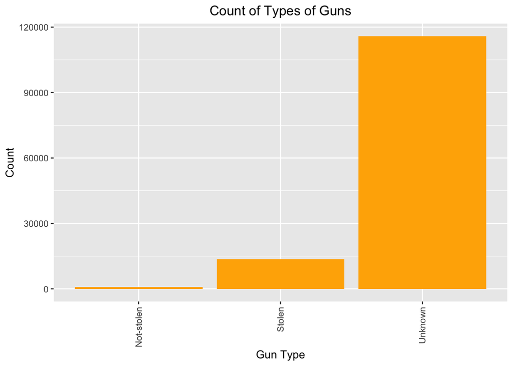

```r
Gun_Info_Stolen_Count <- Gun_Info %>% count(gun_stolen) #Create a data frame of the gun stolen counts

#Plot the data
ggplot(Gun_Info_Stolen_Count, aes(x=gun_stolen, y=n)) +
  geom_bar(stat="identity", fill="#FFB000") +
  labs(x="Gun Type", y="Count")+
  ggtitle("Count of Types of Guns")+
  theme(axis.text.x=element_text(angle=90,hjust=1,vjust=0.5), plot.title = element_text(hjust=0.5))
```

- Once again the unknow amount is high, but it appears that guns involved in incidents are more likely to be stolen

### Exploring our Participant_Incident_Info table

First, lets look at a summary of our data frame

```r
dfSummary(Participant_Incident_Info, style="grid", graph.col=FALSE, max.distinct.values=5, valid.col=FALSE)
```

### Data Frame Summary

**Participant_Incident_Info**  
**Dimensions:** 235459 x 4  
**Duplicates:** 56616

| No | Variable | Stats / Values | Freqs (% of Valid) | Missing |
| --- | --- | --- | --- | --- |
| 1 | incident_id [factor] | 1. 92117 2. 92129 3. 92135 4. 92151 5. 92160 [ 116618 others ] | 2 ( 0.0%) 1 ( 0.0%) 1 ( 0.0%) 2 ( 0.0%) 1 ( 0.0%) 235452 (100.0%) | 0 (0%) |
| 2 | participant_name [character] | 1. Officer 2. Richard Rodriguez 3. * 4. 52 5. 53 [ 161609 others ] | 538 ( 0.2%) 246 ( 0.1%) 243 ( 0.1%) 196 ( 0.1%) 196 ( 0.1%) 234040 (99.4%) | 0 (0%) |
| 3 | participant_status [factor] | 1. Arrested 2. Injured 3. Injured, Arrested 4. Injured, Unharmed 5. Injured, Unharmed, Arrest [ 7 others ] | 7992 ( 3.4%) 38707 (16.4%) 2839 ( 1.2%) 9 ( 0.0%) 18 ( 0.0%) 185894 (79.0%) | 0 (0%) |
| 4 | participant_type [factor] | 1. Subject-Suspect 2. Victim | 139975 (59.5%) 95484 (40.6%) | 0 (0%) |

```r
summary(Participant_Incident_Info)
```

incident_id participant_name participant_status 577157 : 13272 Length:235459 Unharmed, Arrested:96959  
575663 : 6602 Class :character Killed :62073  
980577 : 4006 Mode :character Injured :38707  
1049217: 2885 Unharmed :26772  
1059740: 2696 Arrested : 7992  
432116 : 1944 Injured, Arrested : 2839  
(Other):204054 (Other) : 117  
participant_type Subject-Suspect:139975  
Victim : 95484

Now, lets take a look at the frequencies of the variables participant_status and participant_type

```r
freq(Participant_Incident_Info$participant_status, plain.ascii = FALSE, style = "rmarkdown", order="freq", rows=1:5)
```

### Frequencies

**Participant_Incident_Info$participant_status**  
**Type:** Factor

|  | Freq | % Valid | % Valid Cum. | % Total | % Total Cum. |
| --- | --- | --- | --- | --- | --- |
| **Unharmed, Arrested** | 96959 | 41.18 | 41.18 | 41.18 | 41.18 |
| **Killed** | 62073 | 26.36 | 67.54 | 26.36 | 67.54 |
| **Injured** | 38707 | 16.44 | 83.98 | 16.44 | 83.98 |
| **Unharmed** | 26772 | 11.37 | 95.35 | 11.37 | 95.35 |
| **Arrested** | 7992 | 3.39 | 98.74 | 3.39 | 98.74 |
| **(Other)** | 2956 | 1.26 | 100.00 | 1.26 | 100.00 |
| **<NA>** | 0 |  |  | 0.00 | 100.00 |
| **Total** | 235459 | 100.00 | 100.00 | 100.00 | 100.00 |

```r
freq(Participant_Incident_Info$participant_type, plain.ascii = FALSE, style = "rmarkdown", order="freq", rows=1:5)
```

```
There are only 2 rows to show; higher numbers will be ignored
```

### Frequencies

**Participant_Incident_Info$participant_type**  
**Type:** Factor

|  | Freq | % Valid | % Valid Cum. | % Total | % Total Cum. |
| --- | --- | --- | --- | --- | --- |
| **Subject-Suspect** | 139975 | 59.45 | 59.45 | 59.45 | 59.45 |
| **Victim** | 95484 | 40.55 | 100.00 | 40.55 | 100.00 |
| **<NA>** | 0 |  |  | 0.00 | 100.00 |
| **Total** | 235459 | 100.00 | 100.00 | 100.00 | 100.00 |

- The most frequent participant status is ‘Unharmed, Arrested’, followed by ‘Killed’
- The most frequent participant status is ‘Subject-Suspect’
  - This is interesting since I beleive there are more shooter victims then shooters. This makes me believe that the dataset does have some inconsistencies when obtaining all the participants involved in the incident. It is probably easier to obtain the suspect’s name than all the victims involved(especially if they don’t want to be in the news).

### Exploring our Participant_Info table

Lets first look at a summary of our table

```r
dfSummary(Participant_Info, style="grid", graph.col=FALSE, max.distinct.values=5, valid.col=FALSE)
```

### Data Frame Summary

**Participant_Info**  
**Dimensions:** 594719 x 5  
**Duplicates:** 430979

| No | Variable | Stats / Values | Freqs (% of Valid) | Missing |
| --- | --- | --- | --- | --- |
| 1 | incident_id [factor] | 1. 92117 2. 92129 3. 92135 4. 92151 5. 92165 [ 106400 others ] | 1 ( 0.0%) 1 ( 0.0%) 1 ( 0.0%) 2 ( 0.0%) 2 ( 0.0%) 594712 (100.0%) | 0 (0%) |
| 2 | participant_name [character] | 1. Richard Rodriguez 2. 52 3. 53 4. Alejandro Barrios Martine 5. Amanda Alvear [ 143653 others ] | 2544 ( 0.4%) 2016 ( 0.3%) 2016 ( 0.3%) 2016 ( 0.3%) 2016 ( 0.3%) 584111 (98.2%) | 0 (0%) |
| 3 | participant_age [numeric] | Mean (sd) : 29.1 (11.8) min < med < max: 0 < 26 < 311 IQR (CV) : 12 (0.4) | 103 distinct values | 1388 (0.23%) |
| 4 | participant_age_group [factor] | 1. Adult 18+ 2. Child 0-11 3. Teen 12-17 | 551679 (92.8%) 11292 ( 1.9%) 31748 ( 5.3%) | 0 (0%) |
| 5 | participant_gender [factor] | 1. Female 2. Male | 112879 (19.0%) 481840 (81.0%) | 0 (0%) |

```r
summary(Participant_Info)
```

incident_id participant_name participant_age participant_age_group 577157 : 93642 Length:594719 Min. : 0.00 Adult 18+ :551679  
575663 : 67052 Class :character 1st Qu.: 21.00 Child 0-11: 11292  
980577 : 30788 Mode :character Median : 26.00 Teen 12-17: 31748  
1059740: 29370 Mean : 29.06  
938183 : 21209 3rd Qu.: 33.00  
1049217: 20620 Max. :311.00  
(Other):332038 NA’s :1388  
participant_gender Female:112879  
Male :481840

- The participant_age_group variable is mostly adults
  - This matches up with the participate_age mean
- We can see that the participats are mostly male
  - Males make up 81% of the participants
  - Females make up 19% of the participants
- We can see some issues with the participant_age variable
  - There is a participant who’s age is logged as 311, making this row ‘dirty’ and most likely an error
  - Lets investigate further to see if there are any other high ages within the dataset

```r
head(sort(Participant_Info$participant_age, decreasing=TRUE), n=150) #view the top 150 sorted from greatest to least
```

[1] 311 101 101 100 99 99 98 97 97 96 96 96 96 96 95 95 94 94 [19] 94 94 94 94 94 93 93 93 93 93 92 92 92 92 92 92 92 92 [37] 92 92 92 92 92 91 91 91 91 91 91 91 91 91 91 91 91 91 [55] 91 90 90 90 90 90 90 90 90 90 90 90 90 90 90 90 90 90 [73] 90 90 90 90 90 90 89 89 89 89 89 89 89 89 89 89 89 89 [91] 89 89 89 89 89 89 89 89 89 89 89 89 88 88 88 88 88 88 [109] 88 88 88 88 88 88 88 88 88 88 88 88 88 88 88 88 88 88 [127] 88 88 88 87 87 87 87 87 87 87 87 87 87 87 87 87 87 87 [145] 87 87 87 87 87 87 * In my opinion 311-100 are unreasonably high, and can potentially be observations that have wrong values + Even up to 89 seems quite high, this is something we can investigate further in the future

Now lets take a closer look at some of our variables to answer a question

> What is the gender percentage within each age group?

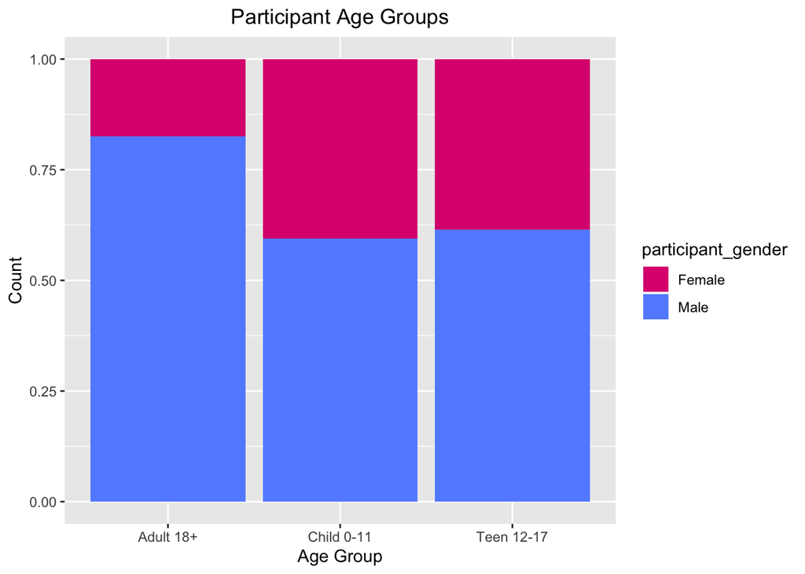

```r
grouped_participant <- Participant_Info %>%
  group_by(participant_gender, participant_age_group) %>%
  summarise(Count=n()) #group together gender and age group

#Plot the data
ggplot(grouped_participant, aes(x=participant_age_group, y=Count, fill=participant_gender)) +
  geom_bar(stat="identity", position="fill") +
  scale_fill_manual(values=c("#DC267F", "#648FFF")) +
  labs(x="Age Group", y="Count")+
  ggtitle("Participant Age Groups")+
  theme(plot.title = element_text(hjust=0.5))
```

- It is interesting to note that the percent of males in the adult age group accurately depicts the overall male to female average. However, the child and teen age groups are signficantly different and have an closer to a 40% female to 60% male ratio.
  - This could potentially be a trend
  - Or this could be due to the fact that the percentage of teens and children in this dataset are relativley low in comparison to the percentage of adults

### Exploring our Incident_Characteristics table

Lets first look at a summary of our table

```r
dfSummary(Incident_Characteristics, style="grid", graph.col=FALSE, max.distinct.values=5, valid.col=FALSE)
```

### Data Frame Summary

**Incident_Characteristics**  
**Dimensions:** 576861 x 2  
**Duplicates:** 0

| No | Variable | Stats / Values | Freqs (% of Valid) | Missing |
| --- | --- | --- | --- | --- |
| 1 | incident_id [factor] | 1. 92114 2. 92117 3. 92119 4. 92122 5. 92125 [ 239672 others ] | 1 ( 0.0%) 3 ( 0.0%) 1 ( 0.0%) 1 ( 0.0%) 1 ( 0.0%) 576854 (100.0%) | 0 (0%) |
| 2 | incident_characteristics [factor] | 1. Accidental Shooting 2. Accidental Shooting - Dea 3. Accidental Shooting - Inj 4. Accidental Shooting at a 5. Accidental Shooting\|Accid [ 666 others ] | 8075 ( 1.4%) 1703 ( 0.3%) 5277 ( 0.9%) 586 ( 0.1%) 5 ( 0.0%) 560889 (97.3%) | 326 (0.06%) |

```r
summary(Incident_Characteristics)
```

incident_id  
599153 : 19  
715888 : 18  
987611 : 18  
574247 : 17  
608308 : 16  
848610 : 16  
(Other):576757  
incident_characteristics Shot - Wounded/Injured : 93313  
Shot - Dead (murder, accidental, suicide) : 52898  
Non-Shooting Incident : 44761  
Shots Fired - No Injuries : 35550  
Possession (gun(s) found during commission of other crimes): 30626  
(Other) :319387  
NA’s : 326  
Now lets take a closer look at some of our variables to answer a question

> What are the most frequent characteristics>

```r
Incident_Characteristics_Count <- Incident_Characteristics %>% count(incident_characteristics) #creating a data frame of counts of each characteristic
```

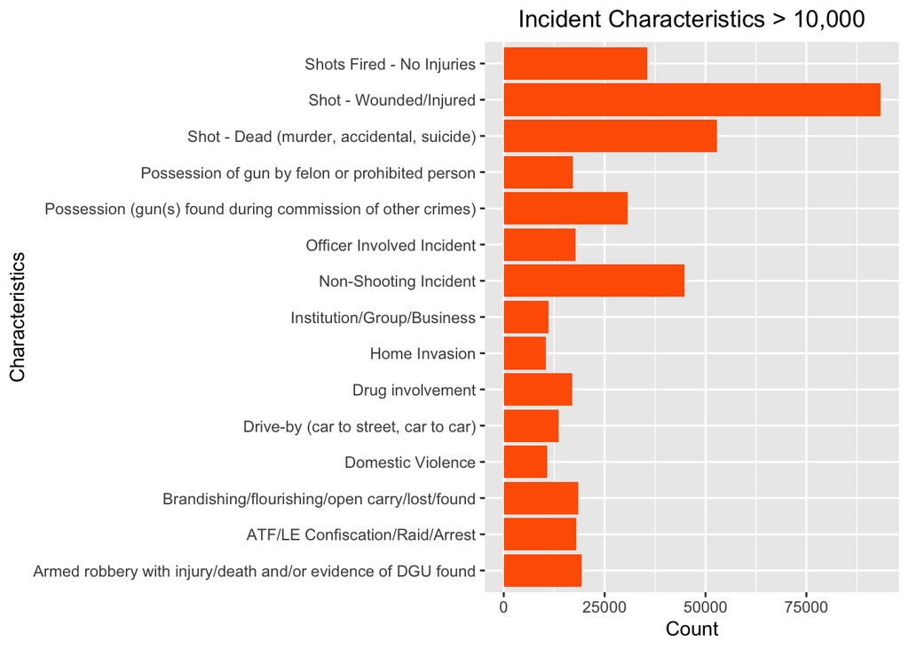

```r
Incident_Characteristics_Count <- Incident_Characteristics_Count %>% filter(n > 10000) #Going to limit the characteristics that have counts greater than 10,000

#Plot the data
ggplot(Incident_Characteristics_Count , aes(x=incident_characteristics, y=n)) +
  geom_bar(stat="identity", fill="#FE6100") +
  labs(x="Characteristics", y="Count")+
  ggtitle("Incident Characteristics > 10,000")+
  coord_flip()+
  theme(plot.title = element_text(hjust=0.5))
```

- The most frequent characteristic is ‘Shot - wounded/injured’ followed by ‘Shot - dead’
  - Shooting seems to be the most frequent
  - This makes sense since the dataset is related to gun violence
- The third most frequent characteristic is ‘Non-Shooting Incident’
  - This seems like an odd characteristic to be frequent
  - We can look into this characteristic in the future

## 5. Research Quetsions

1. How does the prevalence of gun violence in the United States vary from that of other countries? Many exhibit far few instances annually, what are the social, political and economic influences which make this the case? And how may these ideals be implemented to decrease rates of gun violence within the US?
2. Claims made by organizations such as the National Rifle Association attribute the increasing rates of gun violence in the United States to violence in video games. Does a correlation between violent video games, and gun violence exist? Do other countries with similar video game playing trends experience gun violence at the same rate?
3. Some argue that with the implementation of stricter gun laws, people would simply seek out other weapons. Considering countries which have enforced strict gun laws, was a difference in crime rates seen, an increase, decrease, or were the findings insignificant?

Some social and ethical issues that come with this data are human biases and unfair discrimination. Human biases and discrimination can appear throught many different aspects of this data set. For example, when police officers are patrolling, arresting, or targeting citizens in some biased or discriminatory way. Building a model off biased data builds a biased model. Using such information to help improve our society can feed into the reinforcment of such biases, and may also lead to the improvement of select social groups or individuals. Using data from other countries as a proxy to make decisions for a different country can lead poor decision making. Although one model works for one country, that does not mean that the same model will work for another country. Models are not one size fits all, and it may not be possible to mitigate such biases and proxies in order to create a model that will work for all individuals in our society.

Link to Part 2 of Portfolio >